# piyango

yk

10 04 2020

## Piyango oyunlarından Sayısal Loto incelemesi

Sayısal Loto oyunu Milli Piyango idaresi tarafından önceleri haftada bir, şimdilerde haftada iki defa gerçekleştirilen bir oyundur. 1’den 49’a kadar (1 ve 49 dahil) sayılardan 6 adet rakamı tutturan en büyük ikramiyeyi, 5, 4 ve 3 tutturanların daha az ödül alabildiği bir şans oyunudur. Her 6 rakam grubu için 1.5 TL ödeme yapılarak umut aradığımız oyunda oynama kısıtı yoktur. Bu oyun kurgusu 49 rakam içinden 6 rakamı tahmin etme üzerine kuruludur. Bu oyuna ait 1996-2020 yılları arasındaki 1312 adet çekilişi içeren veri incelemesi yapılacaktır.

```r
loto <- read.csv("C:/Users/ykoca/Desktop/R_sample/loto.csv", sep=";", stringsAsFactors = F)
loto$Tarih <- as.Date(loto$Tarih, format = "%d.%m.%Y")
head(loto)
```

```
##   Hafta      Tarih Sayi1 Sayi2 Sayi3 Sayi4 Sayi5 Sayi6
## 1  1312 2020-04-08     5    11    19    20    28    46
## 2  1311 2020-04-04     5    14    25    27    46    49
## 3  1310 2020-04-01     4    10    15    23    30    31
## 4  1309 2020-03-28     2    17    23    27    37    44
## 5  1308 2020-03-25     8    19    31    32    39    46
## 6  1307 2020-03-21     2     7    15    29    40    48
```

## Çıkan sayı istatistiği

Öncelikle çıkan sayı istatistikleri irdeleyeceğiz.

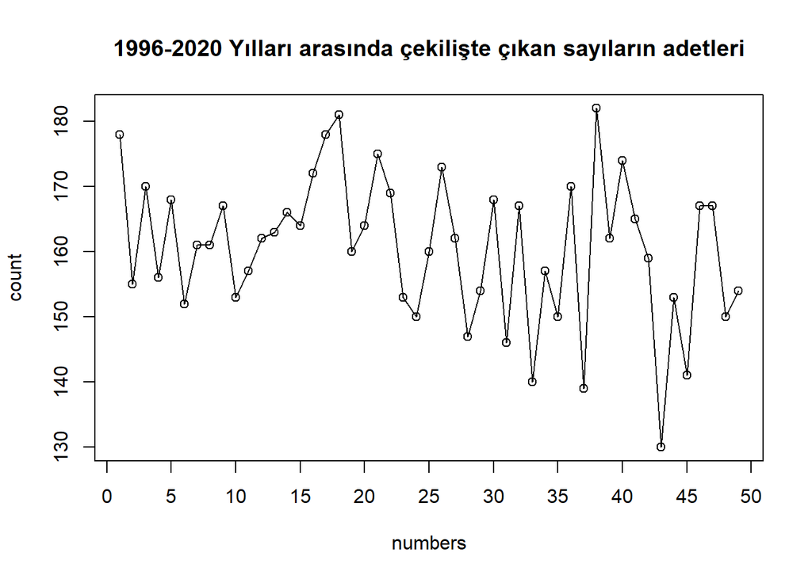

```r
sayihane <- loto[,3:8]
sayilar <- split(sayihane, seq(nrow(sayihane)))
unlist(sayilar) -> v
sayim <- aggregate(data.frame(count = v),
          list(numbers = v),
          length)
plot(sayim, type="o", xaxt="n")
axis(side=1, at=(0:10)*5, labels=c(seq(0,50,5)))
title("1996-2020 Yılları arasında çekilişte çıkan sayıların adetleri")
```

```r
sayim_w <- cbind(sayim, w = prop.table(sayim)[,2])
(olasilik = sayim_w[,c(1,3)])
```

```
##    numbers          w
## 1        1 0.01956689
## 2        2 0.01703858
## 3        3 0.01868748
## 4        4 0.01714851
## 5        5 0.01846763
## 6        6 0.01670881
## 7        7 0.01769814
## 8        8 0.01769814
## 9        9 0.01835770
## 10      10 0.01681873
## 11      11 0.01725844
## 12      12 0.01780807
## 13      13 0.01791799
## 14      14 0.01824777
```

[output cut: 35 more lines]

## Sayı tahmin et

Herbir sayının ağırlığını bildiğimize göre daha isabetli tahminler yapabiliriz. Bilgisayar sizin için en çok çıkan sayı ağırlığını gözeterek 6 adet sayı tahmin edecek. Bu kodu birkaç defa çalıştırarak bir kolon doldurmak mümkün.

```r
hadi <- function(){
  c <- sample(olasilik$numbers, 6, prob = olasilik$w)
  cat("Çektiğin Şanslı 6 Sayı:",c[order(c)])
  cat("\nİyi şanslar")
}

hadi()
```

```
## Çektiğin Şanslı 6 Sayı: 8 17 22 23 30 46
## İyi şanslar
```

## Ne kadar şanslıymışız bakalım

Tahmin sayıları veya yeni başka sayılar ile daha önce çıkan sayıların karşılaştırmasını yapabilirsin. Şanslı numaralarını 24 yıllık rakamlarla kıyaslama yaparak milyoner olmaya ne kadar yaklaştığını görebilirsin.

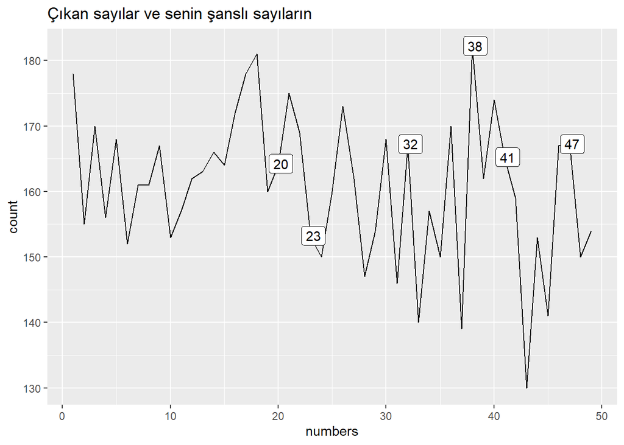

```r
benimki <- c(20,23,32,38,41,47)

ggplot(sayim)+ geom_line(data = sayim, aes(x = numbers, y = count, group = 1L), stat = "identity") +
  geom_label(data = sayim %>% filter(sayim$numbers %in% benimki),
             aes(x = numbers, y = count, label = numbers), nudge_x = 0.25, nudge_y = 0.25) +
  labs(title = "Çıkan sayılar ve senin şanslı sayıların")
```

Bu durumu sayıların ortaya çıkma olasılığı ölçeğinde de görebilirsin.

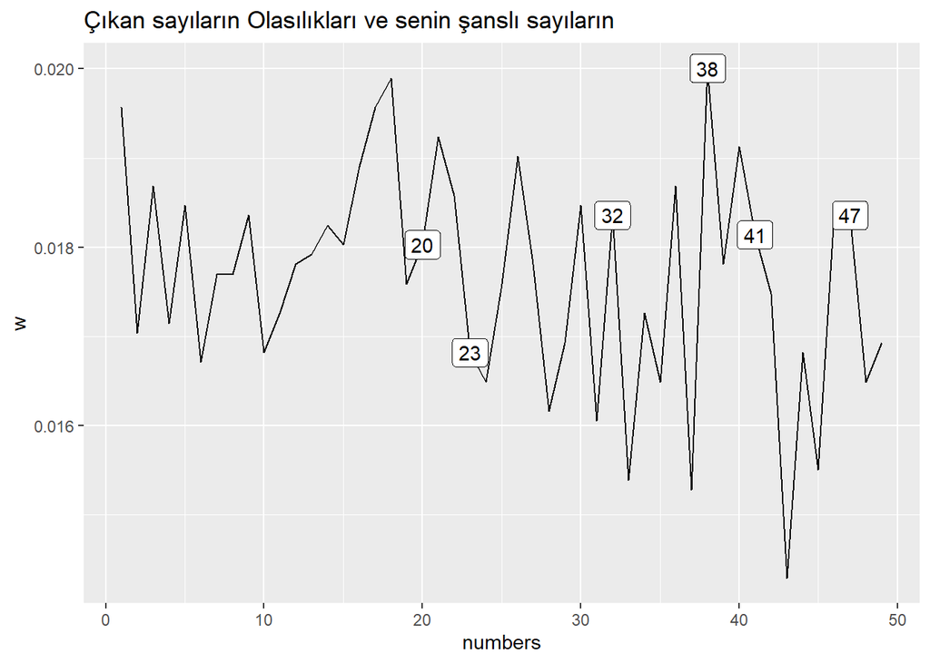

```r
benimki <- c(20,23,32,38,41,47)

ggplot(sayim_w)+ geom_line(data = sayim_w, aes(x = numbers, y = w, group = 1L), stat = "identity") +
  geom_label(data=sayim_w %>% filter(sayim_w$numbers %in% benimki),
             aes(x = numbers, y = w, label = numbers)) +
    labs(title = "Çıkan sayıların Olasılıkları ve senin şanslı sayıların")
```

```r
#         subtitle = paste0("Toplam olasılık :", sum(data$w)))
```